# Donnermeyer_Homework_3

Sam Donnermeyer

9/25/2020

## Hand-In Homework #3

```r
# Read in data files
cranes_df = read_csv("Cranes.csv")

# Create data
waggle_df = tibble("Distance" = c(200, 250, 500, 950, 1950, 3500, 4300), "Duration" = c(.40, .45, .95, 1.30, 2.00, 3.10, 4.10))
```

### Problem 1: Honeybee Waggle Dance

#### **(a)** Create an appropriate scatterplot.

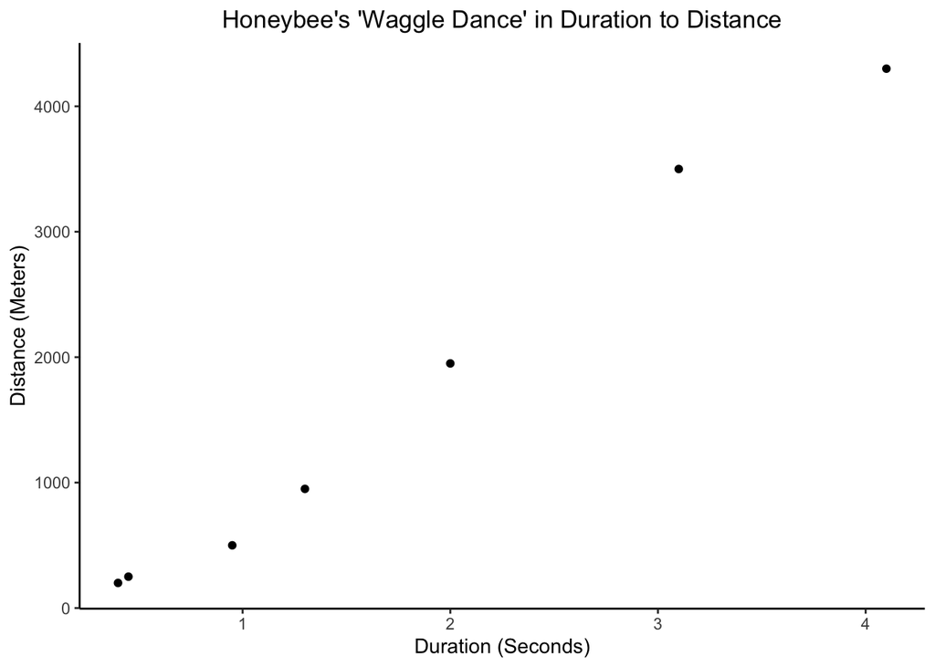

```r
# Create Scatterplot
ggplot(waggle_df, aes(x=Duration, y=Distance)) +
  geom_point() +
  ggtitle("Honeybee's 'Waggle Dance' in Duration to Distance") +
  xlab("Duration (Seconds)") +
  ylab("Distance (Meters)") +
  # Themes
  scale_colour_viridis_d() +
  # Theme
  theme(
    # hide panel borders and remove grid lines
    panel.background = element_rect(fill = "white"),
    panel.border = element_blank(),
    panel.grid.major = element_blank(),
    panel.grid.minor = element_blank(),
    # change axis titles
    axis.line = element_line(color = "black"),
    axis.title = element_text(size=11),
    # Change the title orientation
    plot.title = element_text(hjust = 0.5)
  )
```

There is a strong positive linear relationship between a Honeybee’s ‘Waggle Dance’ duration and the distance from the food source.

#### **(b)** Report the correlation coefficient between duration and distance.

The correlation between the duration of the ‘Waggle Dance’ and the distance from the food source is: 0.994

#### **(c)** Find the equation of the least squares line and write the equation using variable names.

```r
m <- lm(Distance ~ Duration, data=waggle_df)
sm <- summary(m)
sm
```

```
##
## Call:
## lm(formula = Distance ~ Duration, data = waggle_df)
##
## Residuals:
##         1         2         3         4         5         6         7
##  129.3496  120.6367 -216.4921 -177.4822    0.5374  258.8541 -115.4035
##
## Coefficients:
##             Estimate Std. Error t value Pr(>|t|)
## (Intercept)  -399.05     124.10  -3.215   0.0236 *
## Duration     1174.26      56.84  20.661 4.92e-06 ***
## ---
## Signif. codes:  0 '***' 0.001 '**' 0.01 '*' 0.05 '.' 0.1 ' ' 1
##
## Residual standard error: 194.9 on 5 degrees of freedom
## Multiple R-squared:  0.9884, Adjusted R-squared:  0.9861
## F-statistic: 426.9 on 1 and 5 DF,  p-value: 4.918e-06
```

$$\widehat {Distance} = -399.053 + 1174.2576061\,(Duration)$$

#### **(d)** Create a residual plot and a histogram of the residuals (side-by-side). Does it appear there are any problems using a linear model?

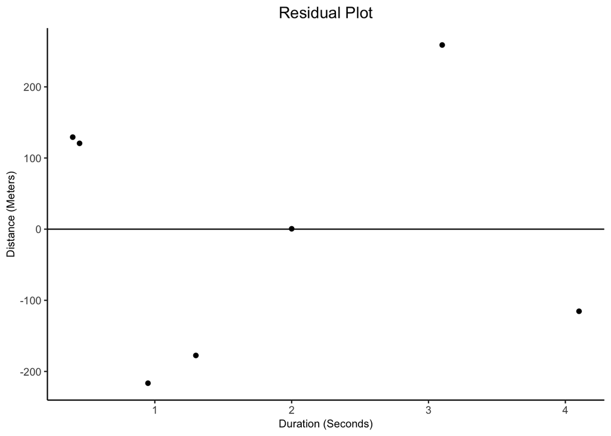

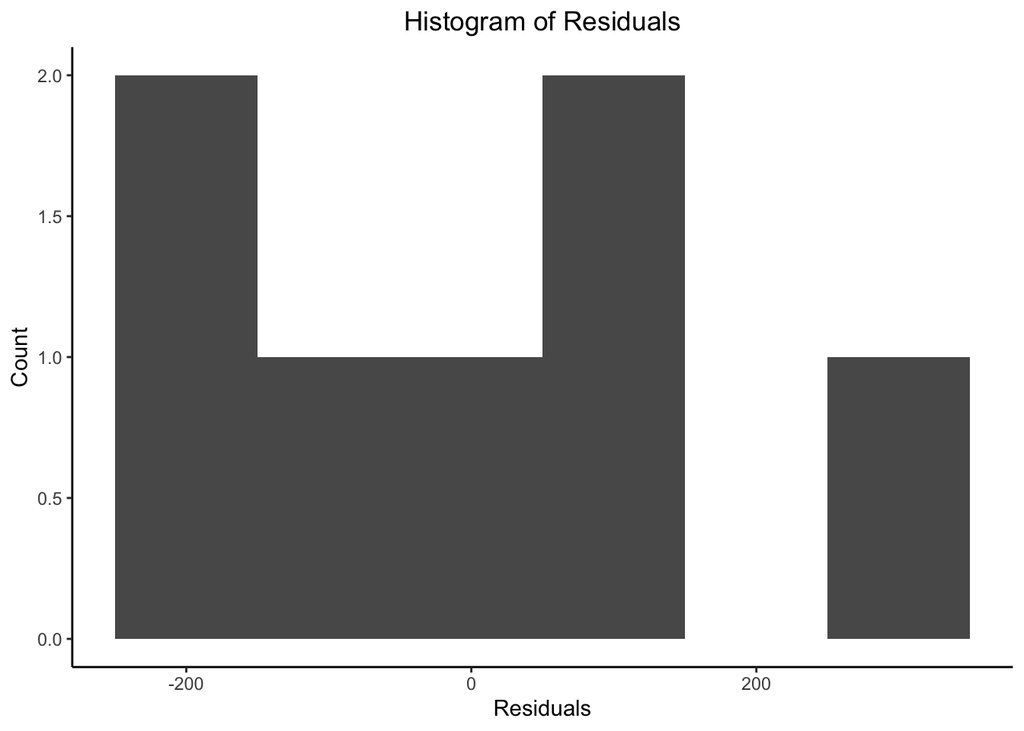

```r
ggplot(waggle_df,aes(x=Duration,y=resid(m))) +
  geom_point() +
  geom_hline(yintercept=0) +
  ggtitle("Residual Plot") +
  xlab("Duration (Seconds)") +
  ylab("Distance (Meters)") +
  # Themes
  scale_colour_viridis_d() +
  # Theme
  theme(
    # hide panel borders and remove grid lines
    panel.background = element_rect(fill = "white"),
    panel.border = element_blank(),
    panel.grid.major = element_blank(),
    panel.grid.minor = element_blank(),
    # change axis titles
    axis.line = element_line(color = "black"),
    axis.title = element_text(size=9),
    # Change the title orientation
    plot.title = element_text(hjust = 0.5)
  )

ggplot(NULL,aes(x=resid(m))) +
  geom_histogram(binwidth=100) +
  ggtitle("Histogram of Residuals") +
  xlab("Residuals") +
  ylab("Count") +
  # Themes
  scale_colour_viridis_d() +
  # Theme
  theme(
    # hide panel borders and remove grid lines
    panel.background = element_rect(fill = "white"),
    panel.border = element_blank(),
    panel.grid.major = element_blank(),
    panel.grid.minor = element_blank(),
    # change axis titles
    axis.line = element_line(color = "black"),
    axis.title = element_text(size=11),
    # Change the title orientation
    plot.title = element_text(hjust = 0.5)
  )
```

The linear model is appropriate to be used with these data, the model is not overfitted and the residuals are evenly distributed.

#### **(e)** Interpret the slope of the regression line. (coef(m)[2]) in the context of the problem.

The slope of the regression line fit to these data predicts that for every additional second elapsed in a honeybee’s Waggle Dance, the distance from the food source would increase by 1174.2576061 meters.

#### **(d)** Report and interpret the values of $R^2$ and $s_e$.

The $R^2$ value represents the variation accounted for by the model. $R^2$: 0.988. This means that 98.8% of variation in the distance from the food source is explained by the duration of the Bee’s Waggle Dance.

The $s_e$ value is 194.924 which indicates that the predictions from this model are expected to be off by about 194.924 meters on average of Bee’s Waggle Dances from the same population.

### Problem 2: Whooping Cranes

#### **(a)** Plot count vs. year (include the plot). With regularly spaced data over time.

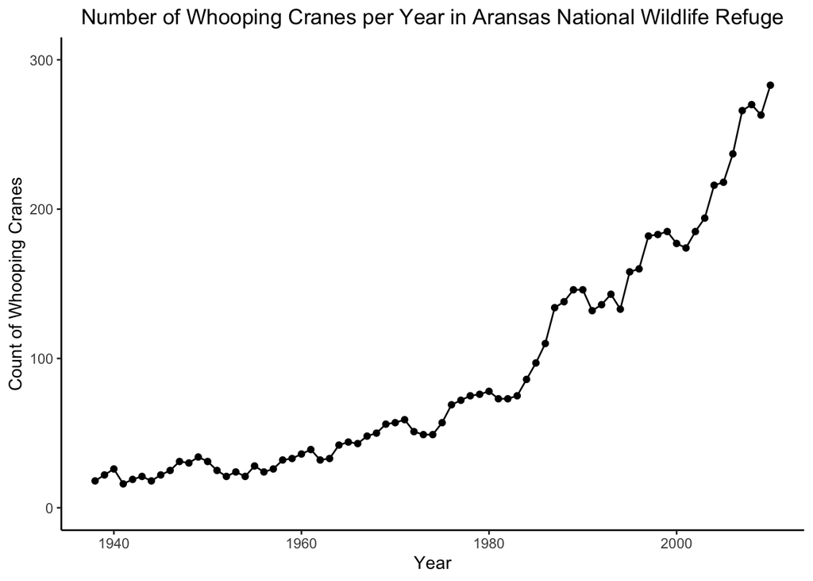

```r
ggplot(cranes_df, aes(x=cranes_df$Year, y=cranes_df$Count)) +
  geom_point() +
  geom_line() +
  ggtitle("Number of Whooping Cranes per Year in Aransas National Wildlife Refuge") +
  xlab("Year") +
  ylab("Count of Whooping Cranes") +
  # Change Axis Frequency
  scale_y_continuous(limits = c(0, 300)) +
  # Themes
  scale_colour_viridis_d() +
  # Theme
  theme(
    # hide panel borders and remove grid lines
    panel.background = element_rect(fill = "white"),
    panel.border = element_blank(),
    panel.grid.major = element_blank(),
    panel.grid.minor = element_blank(),
    # change axis titles
    axis.line = element_line(color = "black"),
    axis.title = element_text(size=11),
    # Change the title orientation
    plot.title = element_text(hjust = 0.5)
  )
```

#### **(b)** Plot log10 of count vs. year (include the plot).

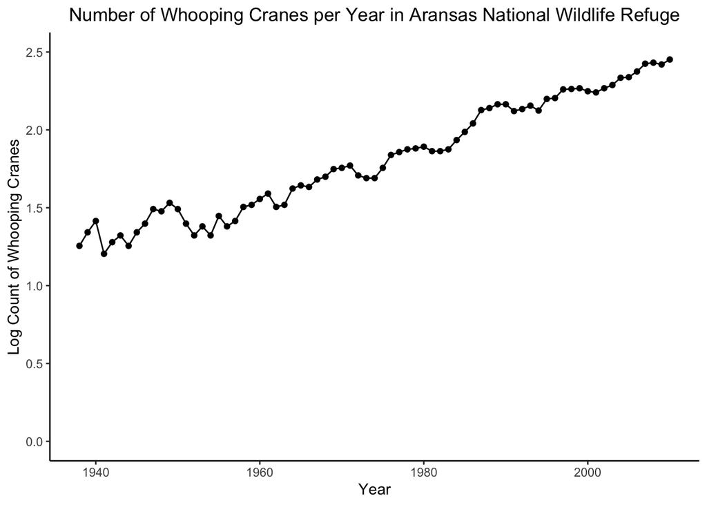

```r
ggplot(cranes_df, aes(x=cranes_df$Year, y=log10(cranes_df$Count))) +
  geom_point() +
  geom_line() +
  ggtitle("Number of Whooping Cranes per Year in Aransas National Wildlife Refuge") +
  xlab("Year") +
  ylab("Log Count of Whooping Cranes") +
  # Change Axis Frequency
  scale_y_continuous(limits = c(0, 2.5)) +
  # Themes
  scale_colour_viridis_d() +
  # Theme
  theme(
    # hide panel borders and remove grid lines
    panel.background = element_rect(fill = "white"),
    panel.border = element_blank(),
    panel.grid.major = element_blank(),
    panel.grid.minor = element_blank(),
    # change axis titles
    axis.line = element_line(color = "black"),
    axis.title = element_text(size=11),
    # Change the title orientation
    plot.title = element_text(hjust = 0.5)
  )
```

#### **(c)** Fit the linear model for predicting log10(Count) from year. Report only the intercept and slope of the model.

```r
# Create Linear model for prediction log10(Count) from year
c_m <- lm(log10(Count) ~ Year, data=cranes_df)
c_sm <- summary(c_m)
```

The intercept of the linear regression model is -31.877, where the coefficient is 0.017. The predicted Whooping Crane population in the Aransas National Wildlife Refuge in Texas would increase by 4.0076615% for every additional year.

The equation of the linear regression model is as follows.
$$\widehat {Log_{10}(Count-of-Whooping-Cranes)} = -31.877 + 0.017\,(Year)$$

#### **(d)** What’s the predicted number of cranes from your model for 2020 and 2050?

The predicted number of Whooping Cranes in the Aransas National Wildlife Refuge for the following years would be:

- 2020: 393.339 Whooping Cranes
- 2050: 1278.577 Whooping Cranes